# Rの基本操作

## 数値型ベクトルの簡単な作図

```r
# お試しデータ作成
set.seed(1111)
Ex1 <- sample(300:1000, 100, replace = T)
set.seed(11111)
Ex2 <- sample(1:500, 100, replace = T)
```

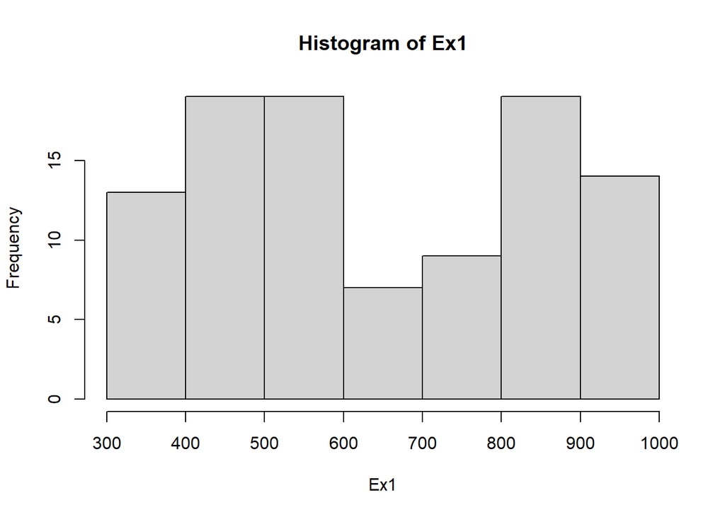

```r
# ヒストグラムを描く
hist(Ex1)
```

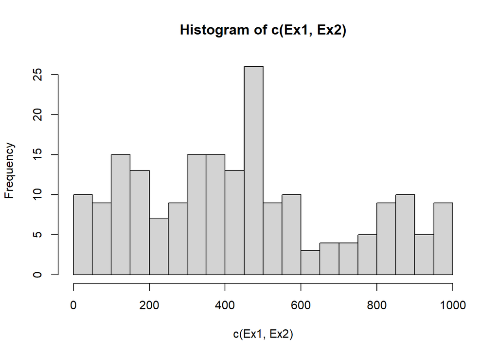

```r
# ヒストグラムのbinの数を指定する
hist(c(Ex1, Ex2), breaks = 20)
```

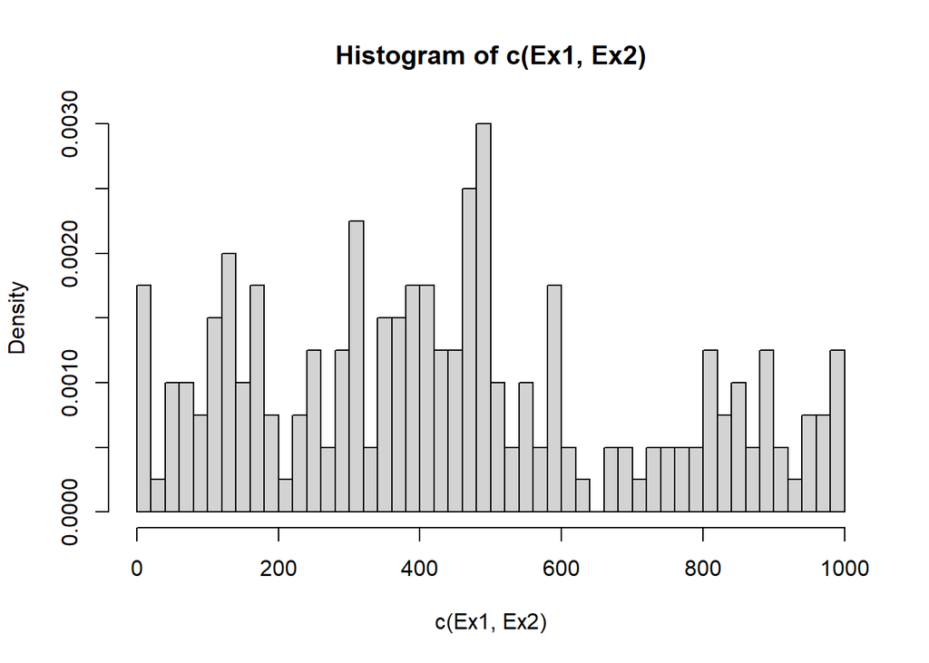

```r
# 頻度を確率に変更
hist(c(Ex1, Ex2), breaks = 50, freq = F)
```

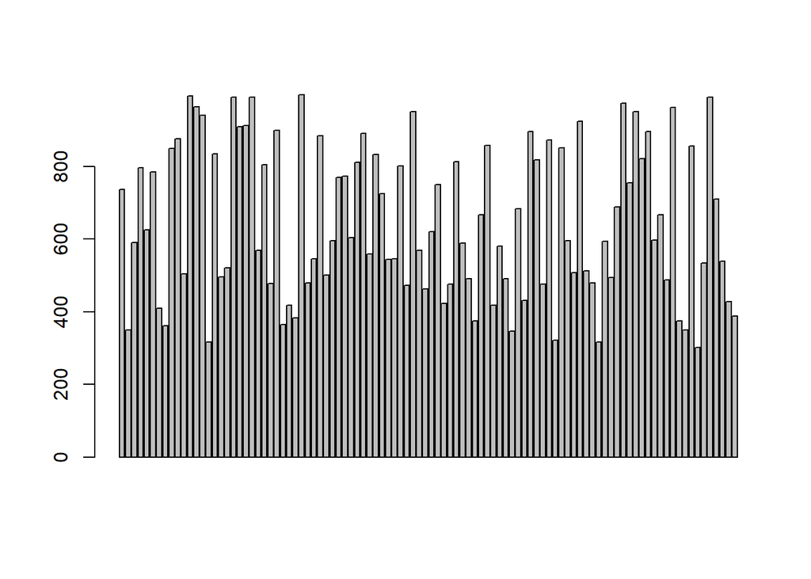

```r
# 棒グラフを描く
barplot(Ex1)
```

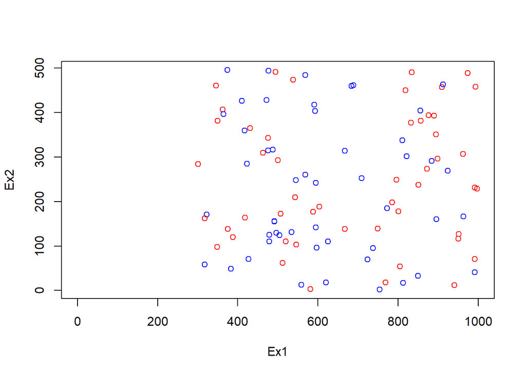

```r
# 散布図を描く
plot(Ex1, Ex2, col = c("blue", "red"), xlim = c(0, 1000))
```

Rの基本描画コマンドはデータの分布などを可視化するのに使用しますが、綺麗なグラフを描くのには細かいパラメーター設定が必要となります。

## 数値型ベクトルの記述統計量の算出

数値型ベクトルに対して実行可能な関数を紹介します。

```r
# お試しデータ作成。長さが100（要素数が100個の数値ベクトル）
set.seed(1111)
Ex <- sample(1000, 100)
```

合:計 $\sum_{i = 1}^{N}X_i$

```r
sum(Ex)
```

```
## [1] 52775
```

平均: $\frac{\sum_{i = 1}^{N}X_i}{N}$

```r
mean(Ex)
```

```
## [1] 527.75
```

中央値

```r
median(Ex)
```

```
## [1] 543
```

最大値

```r
max(Ex)
```

```
## [1] 991
```

最小値

```r
min(Ex)
```

```
## [1] 18
```

四分位

```r
quantile(Ex)
```

```
##     0%    25%    50%    75%   100%
##  18.00 256.75 543.00 782.00 991.00
```

データの要約

```r
summary(Ex)
```

```
##    Min. 1st Qu.  Median    Mean 3rd Qu.    Max.
##    18.0   256.8   543.0   527.8   782.0   991.0
```

不偏分散: $\frac{\sum_{i = 1}^{N}(X_i-\bar{X})^2}{N-1}$ [$\frac{\sum_{i = 1}^{N}(Xのi番目-Xの平均)^2}{サンプル数 - 1}$]  
偏差 (各データの平均との差)を2乗して、Nの数だけ合計。それをN-1で割った値。集団のばらつきの指標。  
Rで分散を求める場合、デフォルトで不偏分散が算出されます。

```r
var(Ex)
```

```
## [1] 84286.01
```

不偏標準偏差: $\sqrt{\frac{\sum_{i = 1}^{N}(X_i-\bar{X})^2}{N-1}}$ [$\sqrt{不偏分散}$]  
分散は2乗された値なので平方根でスケールを戻したもの。  
Rで標準偏差を求める場合、不偏標準偏差になります。(不偏標準偏差という言い方は語弊もあるので、気をつけてください。)

```r
sd(Ex)
```

```
## [1] 290.3205
```

| 関数式 | 入力式 | 意味 |
| --- | --- | --- |
| max() | max(x) | 最大値：データxの中で最も大きい値 |
| min() | min(x) | 最小値：データxの中で最も小さい値 |
| mean() | mean(x) | 平均：データxの算術平均 |
| median() | median(x) | 中央値：データxを昇順に並べた時の真ん中の値。データが偶数の場合は中心の両側にある値から加重平均によって求められる。 |
| quantile() | quantile(x) | 分位点：データxを昇順に並べた時の分位点 |
| range() | range(x) | 範囲：最大値から最小値の差 |
| sd() | sd(x) | 標準偏差：不偏分散の平方根 |
| var() | var(x) | 不偏分散：偏差平方和を(データ数-1)で割った値。 |

# 数値型ベクトルの簡単な有意差検定 2群間比較

```r
# お試しデータ作成
set.seed(1111)
Ex1 <- sample(100, 10)
set.seed(11111)
Ex2 <- sample(50, 10)
```

## – 平均値の差の検定 (パラメトリック検定) –

#### – Welchのtテスト –

※ **比較する2群が正規分布しているのが前提**

```r
t.test(Ex1, Ex2)
```

```
##
##  Welch Two Sample t-test
##
## data:  Ex1 and Ex2
## t = 2.8486, df = 17.131, p-value = 0.01104
## alternative hypothesis: true difference in means is not equal to 0
## 95 percent confidence interval:
##   5.55953 37.24047
## sample estimates:
## mean of x mean of y
##      53.2      31.8
```

#### – Student t test –

※ 比較する2群が**正規分布**かつ**等分散**しているのが前提

```r
t.test(Ex1, Ex2, var.equal = TRUE)
```

```
##
##  Two Sample t-test
##
## data:  Ex1 and Ex2
## t = 2.8486, df = 18, p-value = 0.01066
## alternative hypothesis: true difference in means is not equal to 0
## 95 percent confidence interval:
##   5.617117 37.182883
## sample estimates:
## mean of x mean of y
##      53.2      31.8
```

#### – 対応あるt test –

実際にはt.test関数のpairedオプションをTrueにするだけです。もちろん引数に指定する2つのベクトルの要素順は対応順にしておく必要があります。

```r
t.test(Ex1, Ex2, paired = T)
```

```
##
##  Paired t-test
##
## data:  Ex1 and Ex2
## t = 2.6565, df = 9, p-value = 0.02619
## alternative hypothesis: true mean difference is not equal to 0
## 95 percent confidence interval:
##   3.176877 39.623123
## sample estimates:
## mean difference
##            21.4
```

#### – 正規分布の検定 –

**T検定をする前に正規分布かどうかを確かめておく必要がある。** まずはヒストグラムから正規分布と言えるかどうかを確かめることが第一。

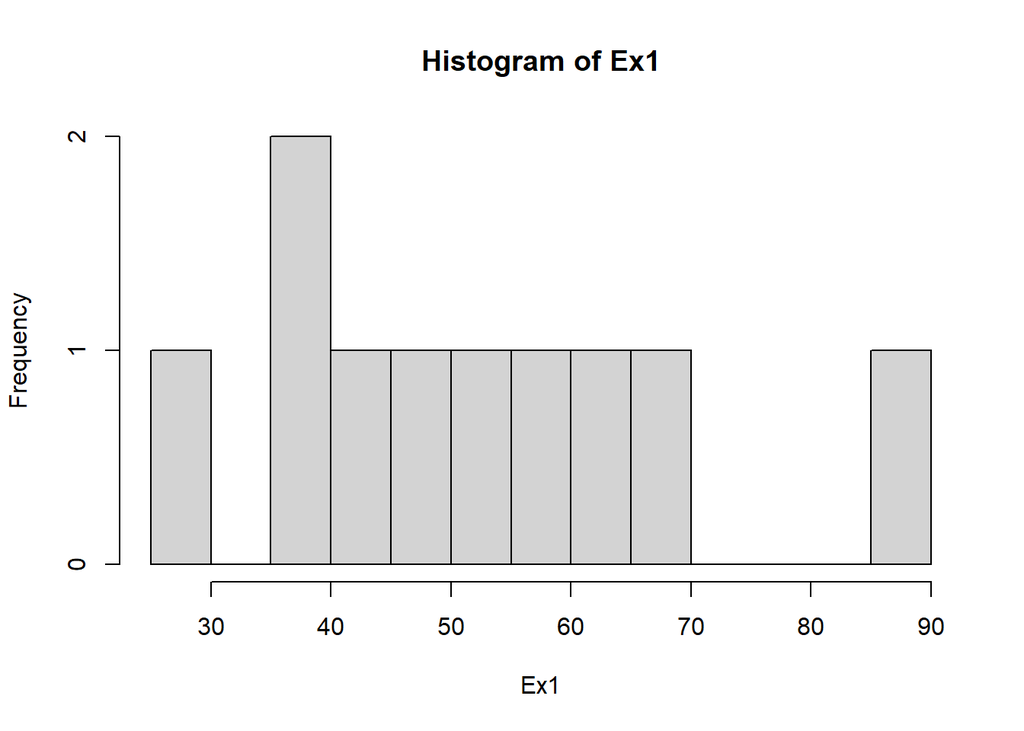

```r
hist(x = Ex1, breaks = 10)
```

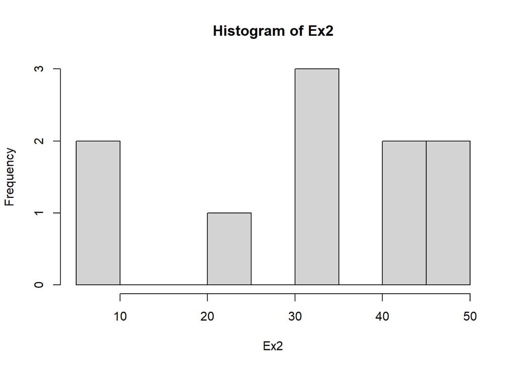

```r
hist(x = Ex2, breaks = 10)
```

shapiro-wilk test。帰無仮説は正規分布していることなので、0.05以上であれば正規分布。

```r
shapiro.test(Ex1)
```

```
##
##  Shapiro-Wilk normality test
##
## data:  Ex1
## W = 0.97826, p-value = 0.9552
```

```r
shapiro.test(Ex2)
```

```
##
##  Shapiro-Wilk normality test
##
## data:  Ex2
## W = 0.89846, p-value = 0.2107
```

Q-Qプロットで正規性を確認する方法もある。※ 検定値は出ない。

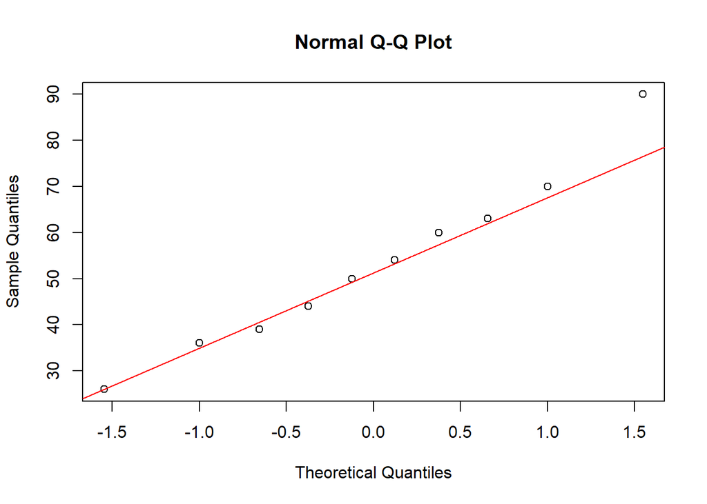

```r
# 縦軸が標本の分位数。横軸が標本を標準分布させたときの何SD分なのかの値。正規分布していれば直線上に乗る。
qqnorm(Ex1)
qqline(Ex1, col = "red")
```

#### – 等分散の検定 F検定 – 帰無仮説は2群の分散が同じ。0.05以上であれば等分散。

```r
var.test(Ex1, Ex2)
```

```
##
##  F test to compare two variances
##
## data:  Ex1 and Ex2
## F = 1.5814, num df = 9, denom df = 9, p-value = 0.5055
## alternative hypothesis: true ratio of variances is not equal to 1
## 95 percent confidence interval:
##  0.3928021 6.3667836
## sample estimates:
## ratio of variances
##           1.581419
```

## – 群間差のノンパラメトリック検定 –

正規分布が仮定できないとき。 ウィルコクソンの順位和検定 (マン-ホイットニーのU検定 (Mann-Whitney U test) と同じ)

```r
wilcox.test(Ex1, Ex2)
```

```
##
##  Wilcoxon rank sum exact test
##
## data:  Ex1 and Ex2
## W = 82, p-value = 0.01469
## alternative hypothesis: true location shift is not equal to 0
```

ウィルコクソンの符号順位検定。対応のあるノンパラメトリック検定

```r
wilcox.test(Ex1, Ex2, paired = T)
```

```
## Warning in wilcox.test.default(Ex1, Ex2, paired = T): タイがあるため、正確な p
## 値を計算することができません
```

```
##
##  Wilcoxon signed rank test with continuity correction
##
## data:  Ex1 and Ex2
## V = 48.5, p-value = 0.03654
## alternative hypothesis: true location shift is not equal to 0
```

※ 値の順位を用いる検定では同値があると正確なp値を出せないという警告が出る。  
(対応ありの場合、各要素の差の絶対値に順位付けされる。)

## – 相関・共分散 –

```r
# ピアソン相関係数を得る。
cor(Ex1, Ex2)
```

```
## [1] -0.1538185
```

```r
# スピアマンの相関係数を得る。
cor(Ex1, Ex2, method = "spearman")
```

```
## [1] -0.1393939
```

相関係数の有意差検定。

```r
# 相関解析 (デフォルトはpearson)
cor.test(Ex1, Ex2)
```

```
##
##  Pearson's product-moment correlation
##
## data:  Ex1 and Ex2
## t = -0.4403, df = 8, p-value = 0.6714
## alternative hypothesis: true correlation is not equal to 0
## 95 percent confidence interval:
##  -0.7142691  0.5268304
## sample estimates:
##        cor
## -0.1538185
```

各群が正規分布していないのであればデータの順位から検定するスピアマンの相関解析を選択する。